# A5- Gun violences in 2018

Vivian Wen

5/19/2020

## **Summary Information**

### Overview

In 2018, there were 340 cases of shootings occurred in the USA. Among the people who were impacted by the gun violences, 373 lives were lost. Besides, from all the cities that shooting occurred, Chicago was most impacted because it had the most number of people killed and injured in these shooting tragedies. Among all states, Delaware had the highest death rate, and the death rate was about 100 percent, which was really horrible. Indeed, February contained the highest number of deaths among all months in 2018.

### Original data source

This report is based on the orginal data from: [MASS SHOOTINGS](http://www.shootingtracker.com/)

## **Summary Table**

The table below shows the top 6 states which had high death rate in 2018 nd displays the number of shooting occurred in each state, the number of impacted people as well as the death rate in two decimal points.

|  | State | Cases | Number of Death | Number of Impacted | Death Rate |
| --- | --- | --- | --- | --- | --- |
| 1 | Delaware | 1 | 5 | 5 | 1.00 |
| 2 | New Mexico | 2 | 5 | 9 | 0.56 |
| 3 | Arizona | 2 | 4 | 9 | 0.44 |
| 4 | Pennsylvania | 19 | 35 | 98 | 0.36 |
| 5 | Texas | 16 | 29 | 91 | 0.32 |
| 6 | Washington | 3 | 4 | 13 | 0.31 |

For example, from the table, we can conclude that:

- Delaware had the highest death rate(100%),which means that people who were impacted by the incidence were all kiied by shooting.
- From the top six of states who had high death rate, Pennsylvania had the most cases of shootings and the highest number of death.
- As we know from our summary, even though Chicago had the most people dead and killed, the state Illinois didn’t have the highest/high death rate.

## **Description of a particular incident**

Among all shooting incident, there was one case caused 100 percent death rate included all people who were impacted that made me really impressive. In July 9, 2018, it should be a normal day for most of people and family, but in Wilmington Delaware, a tragedy happened. Near 2709 Ferris Rd and about lattitude 39.744655 and longitude -75.5483909, a shooting accident took place. Though it was not a mass shooting and 0 people injured from the incident, 5 were killed including children. What a tradedy for the poor family! To get more detailed information, here is a news with video that talkes about this incident: [Police: Man killed wife, 3 children, then himself in Prices Corner, Delaware](https://6abc.com/police-man-killed-wife-3-children-then-himself-in-prices-corner/3734627/).

## **Interactive Map**

Below is a interactive map that shows the shooting cases(including some data such as date and number of death) in each state and city as well as the exact location(latitude and longitude) of shooting took place in USA, 2018. The locations of the red circled marker represent the locations of incidences, and the size of each marker is based on the total number of people impacted in each incidence that we calculate from the number of people injured and killed. The bigger the dot, the more people impacted by gun shootings. Besides, since it’s interactive, users can click each marker to look at the date of the incidence, address it took place, and number of people dead in each incidence.

[interactive chart not shown]

### Some facts from the map:

- Most incidences happened around the Coast or Great lakes.
- The east coast of United States had more cases and more people impacted by gun violence than the west coast.
- States in the north or central US had less cases or no case of shooting.

## **Plot**

1. The boxplots below shows the number of people killed by gun shooting in each month, and the month is ordered from the lowest of number killed to the highest. From each boxplot, we cana see the median value of people lost in each month, the highest number killed as well as the lowest. Besides, the red “stars” shows the outliers of each month.
2. I chose this plot because it’s so straight forward if we want to compare the which month had the highest or lowerst number, and find the distributions and patterns. If we use other plot such as bar chart or pine chart, we can only get the comparision from each month but we cannot see the value of outliers and the distributions of cases of death in each month.

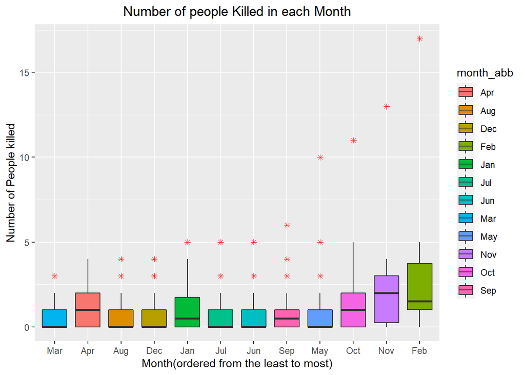

### Several facts from this plot:

- From the plot, the least people dead from March whereas highest the number of people dead in February.
- November had the highest average of death caused by gun shooting in 2018.
- Since February contains the biggest outliers, the insidence happend in February with 15 and more people killed was abnormal from all cases in other month.